# ADAS Utils vignette

# Factorial plans

The package provides tools for dealing with factorial plan according to the *Design of Experiments* (DoE) protocols. The functions for dealing with DoE have names starting with `fp_`. As much as possible, we are aiming at a tidyverse-like syntax, so that the functions can be used in a pipe.

We are following conventions and techniques illustrated in the book *Design and Analysis of Experiments* by Douglas C. Montgomery.

## Full factorial plan

You can create a full factorial plan with the `fp_design_matrix` function, passing the number of factors:

```r
(dm <- fp_design_matrix(2, rep=2) %>%
  mutate(Y=rnorm(n())))
```

```
#>  Factorial Plan Design Matrix
#>  Defining Relationship:  ~ A * B
#>  Factors:  A B
#>  Levels:  -1 1
#>  Fraction:  NA
#>  Type:  plain
#>
#> # A tibble: 8 × 7
#>   StdOrder RunOrder .treat  .rep     A     B      Y
#>      <int>    <int> <chr>  <int> <dbl> <dbl>  <dbl>
#> 1        1        3 (1)        1    -1    -1 -0.489
#> 2        2        2 a          1     1    -1 -0.560
#> 3        3        8 b          1    -1     1 -0.550
#> 4        4        1 ab         1     1     1 -0.178
#> 5        5        4 (1)        2    -1    -1  0.794
#> 6        6        6 a          2     1    -1  0.882
#> 7        7        5 b          2    -1     1 -0.305
#> 8        8        7 ab         2     1     1  0.588
```

In this case, the factors are the first `n` capital letters.

If you want different factor names, use a right-side-only formula combining all the named factors with `*`:

```r
fp_design_matrix(~Speed*Weight)
```

```
#>  Factorial Plan Design Matrix
#>  Defining Relationship:  ~ Speed * Weight
#>  Factors:  Speed Weight
#>  Levels:  -1 1
#>  Fraction:  NA
#>  Type:  plain
#>
#> # A tibble: 4 × 7
#>   StdOrder RunOrder .treat       .rep Speed Weight Y
#>      <int>    <int> <chr>       <int> <dbl>  <dbl> <lgl>
#> 1        1        4 (1)             1    -1     -1 NA
#> 2        2        2 speed           1     1     -1 NA
#> 3        3        1 weight          1    -1      1 NA
#> 4        4        3 speedweight     1     1      1 NA
```

**NOTE**, though, that using custom factor names is discouraged, and won’t work as expected if you are using the functions for dealing with **fractional factorial plans**, especially for the analysis of alias structures among factors.

The yield column `Y` must then be completed according to the randomized `RunOrder` column.

It is possible to add custom scales to the factors, and also add names to the factors:

```r
fp_design_matrix(2) %>%
  fp_add_names(A="Temperature", B="Pressure") %>%
  fp_add_scale(A=c(20, 25), B=c(75, 125), suffix=".scaled")
```

```
#>  Factorial Plan Design Matrix
#>  Defining Relationship:  ~ A * B
#>  Factors:  A B
#>  Levels:  -1 1
#>  Fraction:  NA
#>  Type:  plain
#>  Scales suffix: .scaled
#>  Scaled factors:
#>     A.scaled: [20, 25]
#>     B.scaled: [75, 125]
#>  Factor names:
#>     A: Temperature
#>     B: Pressure
#>
#> # A tibble: 4 × 9
#>   StdOrder RunOrder .treat  .rep     A     B A.scaled B.scaled Y
#>      <int>    <int> <chr>  <int> <dbl> <dbl>    <dbl>    <dbl> <lgl>
#> 1        1        3 (1)        1    -1    -1       20       75 NA
#> 2        2        2 a          1     1    -1       25       75 NA
#> 3        3        1 b          1    -1     1       20      125 NA
#> 4        4        4 ab         1     1     1       25      125 NA
```

## Custom levels

If you want a $k^n$ factorial plan with custom levels, pass the `levels` argument. In this case, though, the `.treat` column with Yates’ treatment codes would be `NA`:

```r
fp_design_matrix(2, levels=-1:1)
```

```
#>  Factorial Plan Design Matrix
#>  Defining Relationship:  ~ A * B
#>  Factors:  A B
#>  Levels:  -1 0 1
#>  Fraction:  NA
#>  Type:  plain
#>
#> # A tibble: 9 × 6
#>   StdOrder RunOrder  .rep     A     B Y
#>      <int>    <int> <int> <int> <int> <lgl>
#> 1        1        5     1    -1    -1 NA
#> 2        2        7     1     0    -1 NA
#> 3        3        8     1     1    -1 NA
#> 4        4        4     1    -1     0 NA
#> 5        5        9     1     0     0 NA
#> 6        6        1     1     1     0 NA
#> 7        7        2     1    -1     1 NA
#> 8        8        6     1     0     1 NA
#> 9        9        3     1     1     1 NA
```

## Interaction plot and response surface

Let’s see a full example that defines a $3\cdot 2^2$ full factorial plan with factor names and scales, creates a linear model and creates the interaction plot and the response surface for the model, using the factor scales on secondary axes:

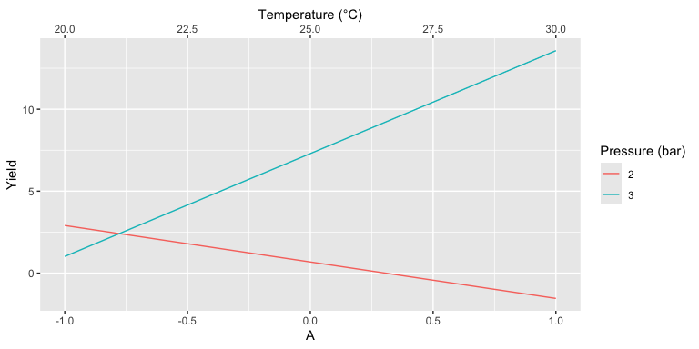

```r
fp <- fp_design_matrix(2, rep=3) %>%
  fp_add_names(A="Temperature (°C)", B="Pressure (bar)") %>%
  fp_add_scale(A=c(20,30), B=c(2, 3))
fp$Y <- ccd_experiment_yield$base
fp.lm <- lm(Y~A*B, data=fp)

fp %>%
  mutate(
    pred = predict(fp.lm),
    B=factor(B)
  ) %>%
  ggplot(aes(x=A, y=pred, color=B)) +
  geom_line() +
  scale_x_continuous(sec.axis = fp_scaled_axis(fp, "A"))+
  scale_color_discrete(labels = fp_scale(fp, "B")) +
  labs(color=fp_name(fp, "B"), y="Yield")
```

Now let’s create the corresponding response surface:

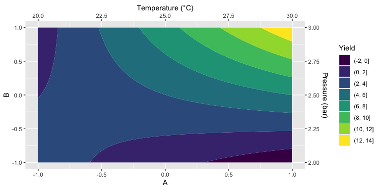

```r
expand.grid(
  A = seq(-1, 1, length.out=100),
  B = seq(-1, 1, length.out=100)
) %>% {
  mutate(., Y=predict(fp.lm, newdata=.))
} %>%
  ggplot(aes(x=A, y=B, z=Y)) +
  geom_contour_filled() +
  scale_x_continuous(sec.axis = fp_scaled_axis(fp, "A")) +
  scale_y_continuous(sec.axis = fp_scaled_axis(fp, "B")) +
  labs(fill="Yield")
```

## Augment a plan

You can augment a plan by adding a central point, typically repeated:

```r
fp_design_matrix(3) %>%
  fp_augment_center(rep=4)
```

```
#>  Factorial Plan Design Matrix
#>  Defining Relationship:  ~ A * B * C
#>  Factors:  A B C
#>  Levels:  -1 1
#>  Fraction:  NA
#>  Type:  centered
#>
#> # A tibble: 12 × 8
#>    StdOrder RunOrder .treat  .rep     A     B     C Y
#>       <int>    <int> <chr>  <int> <dbl> <dbl> <dbl> <lgl>
#>  1        1        3 (1)        1    -1    -1    -1 NA
#>  2        2        7 a          1     1    -1    -1 NA
#>  3        3        1 b          1    -1     1    -1 NA
#>  4        4        4 ab         1     1     1    -1 NA
#>  5        5        2 c          1    -1    -1     1 NA
#>  6        6        8 ac         1     1    -1     1 NA
#>  7        7        6 bc         1    -1     1     1 NA
#>  8        8        5 abc        1     1     1     1 NA
#>  9        9       11 center     1     0     0     0 NA
#> 10       10        9 center     2     0     0     0 NA
#> 11       11       10 center     3     0     0     0 NA
#> 12       12       12 center     4     0     0     0 NA
```

Then if needed (because the analysis show low p-value for the quadratic term) you can add axial points to get a central composite design:

```r
fp_design_matrix(3) %>%
  fp_augment_center(rep=3) %>%
  fp_augment_axial(rep=2)
```

```
#>  Factorial Plan Design Matrix
#>  Defining Relationship:  ~ A * B * C
#>  Factors:  A B C
#>  Levels:  -1 1
#>  Fraction:  NA
#>  Type:  composite
#>
#> # A tibble: 23 × 8
#>    StdOrder RunOrder .treat  .rep     A     B     C Y
#>       <int>    <int> <chr>  <int> <dbl> <dbl> <dbl> <lgl>
#>  1        1        6 (1)        1    -1    -1    -1 NA
#>  2        2        1 a          1     1    -1    -1 NA
#>  3        3        8 b          1    -1     1    -1 NA
#>  4        4        2 ab         1     1     1    -1 NA
#>  5        5        4 c          1    -1    -1     1 NA
#>  6        6        5 ac         1     1    -1     1 NA
#>  7        7        3 bc         1    -1     1     1 NA
#>  8        8        7 abc        1     1     1     1 NA
#>  9        9       11 center     1     0     0     0 NA
#> 10       10        9 center     2     0     0     0 NA
#> # ℹ 13 more rows
```

### Full example

Let’s see a full example using the `ccd_experiment_yield` dataset, which contains a list of the yield data for three sequential experiments in a central composite design.

First, we design a $3\cdot 2^2$ factorial plan, with two factors and two levels each:

```r
fp <- fp_design_matrix(2, rep=3)
```

Ideally, we would then sort the table according to the `RunOrder` column, and complete the `Y` column with the yield data from the the real experiments. For the sake of documenting the package, we can directly add the yield data from the `base` field of the `ccd_experiment_yield` dataset (which holds values **in standard Yates’ order**):

```r
fp$Y <- ccd_experiment_yield$base
```

Now we can fit a linear model to the data, and check the p-values of the ANOVA:

```r
fp %>%
  lm(Y ~ A*B, data=.) %>%
  anova()
```

```
#> Analysis of Variance Table
#>
#> Response: Y
#>           Df  Sum Sq Mean Sq F value    Pr(>F)
#> A          1  49.331  49.331  105.06 7.058e-06 ***
#> B          1 131.224 131.224  279.46 1.659e-07 ***
#> A:B        1 216.931 216.931  461.99 2.311e-08 ***
#> Residuals  8   3.756   0.470
#> ---
#> Signif. codes:  0 '***' 0.001 '**' 0.01 '*' 0.05 '.' 0.1 ' ' 1
```

All factors and their interactions are significant. But is the two-level model enough? Let’s check for the quadratic terms, by augmenting the plan with a central point repeated 4 times. We also load the `center` field from the `ccd_experiment_yield` dataset:

```r
fpc <- fp %>%
  fp_augment_center(rep=4)

fpc$Y[fpc$.treat == "center"] <- ccd_experiment_yield$center
```

Now we can fit a model with the quadratic term, using either $A$ or $B$: since we only have a central point, we cannot discriminate which factor is contributing to the curvature in the response surface. We get:

```r
fpc %>%
  lm(Y ~ A*B+I(A^2), data=.) %>%
  anova()
```

```
#> Analysis of Variance Table
#>
#> Response: Y
#>           Df  Sum Sq Mean Sq F value    Pr(>F)
#> A          1  49.331  49.331  96.801 8.695e-07 ***
#> B          1 131.224 131.224 257.494 5.592e-09 ***
#> I(A^2)     1  15.204  15.204  29.834 0.0001972 ***
#> A:B        1 216.931 216.931 425.673 3.827e-10 ***
#> Residuals 11   5.606   0.510
#> ---
#> Signif. codes:  0 '***' 0.001 '**' 0.01 '*' 0.05 '.' 0.1 ' ' 1
```

So the contribution of the quadratic term **is significant**. This means that we have to further augment the plan with axial points and investigate a *Central Composite Design* (CCD). **Note**: if the quadratic term contribution were not significant, we would have to remove the quadratic term from the model and accept the two-level model.

So let’s load the axial points from the `axial` field of the `ccd_experiment_yield` dataset, and fit a model with the quadratic terms and their interactions:

```r
fpccd <- fpc %>%
  fp_augment_axial(rep=2)

fpccd$Y[fpccd$.treat == "axial"] <- ccd_experiment_yield$axial

fpccd %>%
  lm(Y ~ A*B*I(A^2)*I(B^2), data=.) %>%
  anova()
```

```
#> Analysis of Variance Table
#>
#> Response: Y
#>               Df  Sum Sq Mean Sq  F value    Pr(>F)
#> A              1  75.196  75.196  94.1952 7.395e-08 ***
#> B              1 194.702 194.702 243.8964 1.097e-10 ***
#> I(A^2)         1 101.355 101.355 126.9638 1.017e-08 ***
#> I(B^2)         1   3.551   3.551   4.4479   0.05216 .
#> A:B            1 216.931 216.931 271.7423 5.087e-11 ***
#> A:I(A^2)       1   0.235   0.235   0.2945   0.59530
#> B:I(A^2)       1   1.046   1.046   1.3106   0.27022
#> I(A^2):I(B^2)  1   0.490   0.490   0.6142   0.44542
#> Residuals     15  11.974   0.798
#> ---
#> Signif. codes:  0 '***' 0.001 '**' 0.01 '*' 0.05 '.' 0.1 ' ' 1
```

So we can finally state that a proper model would be `Y ~ A*B+I(A^2)`:

```r
fpccd %>%
  lm(Y ~ A*B+I(A^2), data=.) %>%
  summary()
```

```
#>
#> Call:
#> lm(formula = Y ~ A * B + I(A^2), data = .)
#>
#> Residuals:
#>      Min       1Q   Median       3Q      Max
#> -1.64925 -0.60624  0.00919  0.65165  1.67506
#>
#> Coefficients:
#>             Estimate Std. Error t value Pr(>|t|)
#> (Intercept)   1.0156     0.3061   3.318  0.00362 **
#> A             1.9390     0.2134   9.088 2.40e-08 ***
#> B             3.1201     0.2134  14.624 8.59e-12 ***
#> I(A^2)        2.9905     0.2834  10.552 2.20e-09 ***
#> A:B           4.2518     0.2754  15.437 3.32e-12 ***
#> ---
#> Signif. codes:  0 '***' 0.001 '**' 0.01 '*' 0.05 '.' 0.1 ' ' 1
#>
#> Residual standard error: 0.9541 on 19 degrees of freedom
#> Multiple R-squared:  0.9714, Adjusted R-squared:  0.9654
#> F-statistic: 161.5 on 4 and 19 DF,  p-value: 2.191e-14
```

## Save to/load from a file

Once the design matrix is prepared, you typically want to save it to a file and use it for collecting data form experiments. You can use the `write.csv` function, but it is recommended to use the `fp_write_csv` function, which will also save the design matrix properties as comments:

```r
dm <-  fp_design_matrix(2) %>%
  fp_add_names(A="Temperature", B="Pressure") %>%
  fp_add_scale(A=c(2, 12), B=c(40, 60), suffix="_s") %>%
  fp_write_csv("design_matrix.csv")
```

Note that the `fp_write_csv` function invisibly returns the same design matrix, so you can use it in a pipe chain. Also, the CVS files has the rows arranged in the same order as the `RunOrder` column (i.e. randomized).

Once the CSV file has been completed, you can load it back into R using the `fp_read_csv` function:

```r
dm <- dm %>%
  fp_read_csv("design_matrix.csv")
```

Note that `fp_read_csv` returns the design matrix reordered according to Yates’ standard order.

## Fractional factorial plan

It is possible to divide a design matrix into a fractional factorial plan using the `fp_fraction` function. The fraction uses a **defining relationship** (*dr*) as $I=ABCD$, which is mapped in R as a one side formula `~A*B*C*D`.

Any fraction is added to the `factorial.plan` object in the `fraction` attribute.

A full $2^n$ factorial plan can be reduced to a fractional factorial plan $2^{n-p}$ by applying the `fp_fraction` function $p$ times. For example, to get a $2^{5-2}$ plan with the defining relationships $I=ABCD$ and $I=BCDE$:

```r
fp_design_matrix(5) %>%
  fp_fraction(~A*B*C*D) %>%
  fp_fraction(~B*C*D*E)
```

```
#>  Factorial Plan Design Matrix
#>  Defining Relationship:  ~ A * B * C * D * E
#>  Factors:  A B C D E
#>  Levels:  -1 1
#>  Fraction:  I=ABCD I=BCDE
#>  Type:  fractional
#>
#> # A tibble: 8 × 12
#>   StdOrder RunOrder .treat  .rep     A     B     C     D     E Y      ABCD  BCDE
#>      <int>    <int> <chr>  <int> <dbl> <dbl> <dbl> <dbl> <dbl> <lgl> <dbl> <dbl>
#> 1        1       17 (1)        1    -1    -1    -1    -1    -1 NA        1     1
#> 2        7       24 bc         1    -1     1     1    -1    -1 NA        1     1
#> 3       11       27 bd         1    -1     1    -1     1    -1 NA        1     1
#> 4       13       31 cd         1    -1    -1     1     1    -1 NA        1     1
#> 5       20        1 abe        1     1     1    -1    -1     1 NA        1     1
#> 6       22       13 ace        1     1    -1     1    -1     1 NA        1     1
#> 7       26       16 ade        1     1    -1    -1     1     1 NA        1     1
#> 8       32       11 abcde      1     1     1     1     1     1 NA        1     1
```

Note that with the `remove` option you can control if you want to keep both fractions, and later on `filter(ABC==1)` them out.

```r
fp_design_matrix(3) %>%
  fp_fraction(~A*B*C, remove=FALSE)
```

```
#>  Factorial Plan Design Matrix
#>  Defining Relationship:  ~ A * B * C
#>  Factors:  A B C
#>  Levels:  -1 1
#>  Fraction:  I=ABC
#>  Type:  fractional
#>
#> # A tibble: 8 × 9
#>   StdOrder RunOrder .treat  .rep     A     B     C Y       ABC
#>      <int>    <int> <chr>  <int> <dbl> <dbl> <dbl> <lgl> <dbl>
#> 1        1        6 (1)        1    -1    -1    -1 NA       -1
#> 2        2        3 a          1     1    -1    -1 NA        1
#> 3        3        1 b          1    -1     1    -1 NA        1
#> 4        4        2 ab         1     1     1    -1 NA       -1
#> 5        5        8 c          1    -1    -1     1 NA        1
#> 6        6        5 ac         1     1    -1     1 NA       -1
#> 7        7        4 bc         1    -1     1     1 NA       -1
#> 8        8        7 abc        1     1     1     1 NA        1
```

## Alias structure

Any fraction of a factorial plan results in a set of *aliases* among effects. The package provides the following functions to deal with alias structures:

- `fp_alias_matrix`: returns a matrix with the alias structure of the factors in the design matrix. The alias matrix has a plot method.
- `fp_all_drs`: given a set of defining relationships, returns the dependent one.
- `fp_merge_drs`: given a set of defining relationships, returns the merged one, i.e. the one having all the factors.
- `fp_gen2alias`: given a *generator* (i.e. the right side of a DR) and an effect name as strings, calculates the resulting alias.

For example:

```r
(am <- fp_alias_matrix(~A*B*C, ~B*C*D))
```

```
#> Defining relationships:
#>  I=ABC I=BCD I=AD
#>
#>      A B AB C AC BC ABC D AD BD ABD CD ACD BCD ABCD
#> A    0 0  0 0  0  1   0 3  0  0   0  0   0   0    2
#> B    0 0  0 0  1  0   0 0  0  0   3  2   0   0    0
#> AB   0 0  0 1  0  0   0 0  0  3   0  0   2   0    0
#> C    0 0  1 0  0  0   0 0  0  2   0  0   3   0    0
#> AC   0 1  0 0  0  0   0 0  0  0   2  3   0   0    0
#> BC   1 0  0 0  0  0   0 2  0  0   0  0   0   0    3
#> ABC  0 0  0 0  0  0   0 0  2  0   0  0   0   3    0
#> D    3 0  0 0  0  2   0 0  0  0   0  0   0   0    1
#> AD   0 0  0 0  0  0   2 0  0  0   0  0   0   1    0
#> BD   0 0  3 2  0  0   0 0  0  0   0  0   1   0    0
#> ABD  0 3  0 0  2  0   0 0  0  0   0  1   0   0    0
#> CD   0 2  0 0  3  0   0 0  0  0   1  0   0   0    0
#> ACD  0 0  2 3  0  0   0 0  0  1   0  0   0   0    0
#> BCD  0 0  0 0  0  0   3 0  1  0   0  0   0   0    0
#> ABCD 2 0  0 0  0  3   0 1  0  0   0  0   0   0    0
```

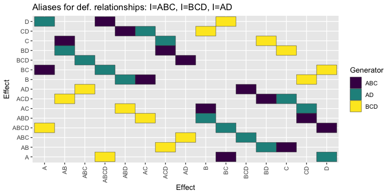

```r
am %>% plot()
```

```r
am %>% as_tibble()
```

```
#> # A tibble: 42 × 3
#>    Effect.x Effect.y generator
#>    <chr>    <chr>    <chr>
#>  1 A        BC       ABC
#>  2 A        D        AD
#>  3 A        ABCD     BCD
#>  4 B        AC       ABC
#>  5 B        ABD      AD
#>  6 B        CD       BCD
#>  7 AB       C        ABC
#>  8 AB       BD       AD
#>  9 AB       ACD      BCD
#> 10 C        AB       ABC
#> # ℹ 32 more rows
```

# Statistics

The package also provides some useful functions for statistical analysis of data.

## Plotting

### Normal probability plot

The normal probability plot is provided as an alternative to the quantile-quantile plot:

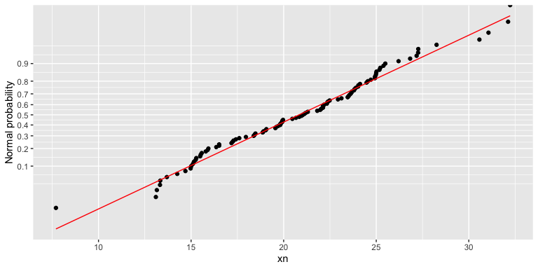

```r
df <- tibble(
  xn = rnorm(100, mean=20, sd=5),
  xu = runif(100, min=0, max=40)
)

df %>% normplot(xn)
```

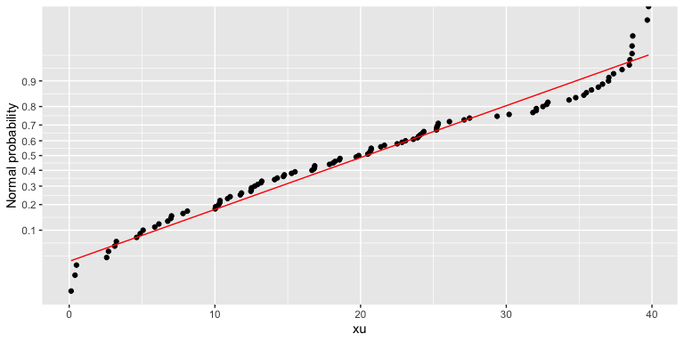

```r
df %>% normplot(xu)
```

### Half-normal probability

There are thre geometries for creating half-normap probability plot of quantiles:

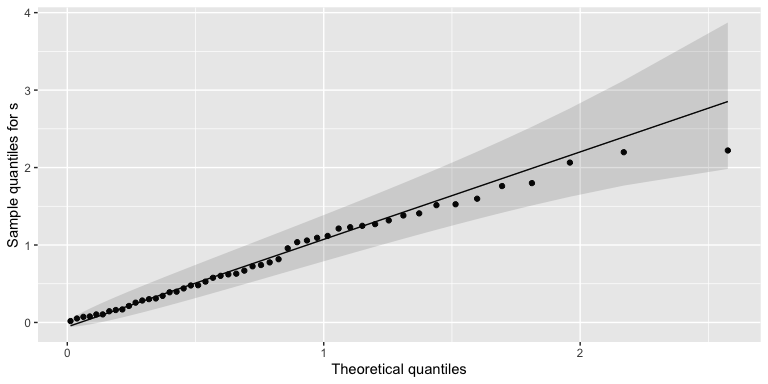

```r
tibble(
  s = rnorm(50),
  lab = paste0("obs_", seq_along(s)),
  group=1
) %>%
  ggplot(aes(sample=s, labels=lab)) +
  geom_qqhn() +
  geom_qqhn_line() +
  geom_qqhn_band(alpha=0.15)
```

These geometries also work on grouped data:

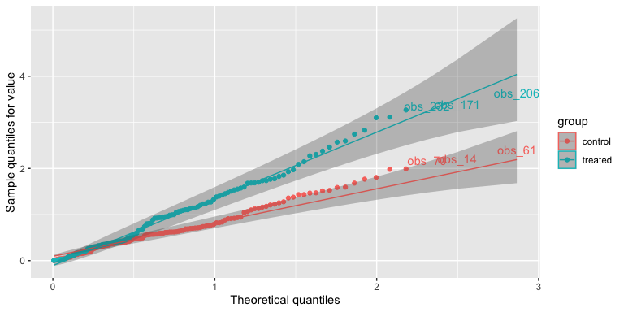

```r
set.seed(1)
df <- data.frame(
  group = rep(c("control", "treated"), each = 120),
  value = c(rnorm(120, mean = 0, sd = 1), rnorm(120, mean = 0.4, sd = 1.3))
)
df$obs_id <- paste0("obs_", seq_len(nrow(df)))

ggplot(df, aes(sample = value, labels = obs_id, colour = group, group = group)) +
  geom_qqhn_band(conf.level = 0.95, linewidth = 0, alpha = 0.15) +
  geom_qqhn(label_n = 3) +
  geom_qqhn_line() +
  geom_qqhn_band(alpha = 0.15)
```

### Pareto chart

The Pareto chart is a bar chart that displays the relative importance of problems in a format that is very easy to interpret. The bars are sorted in descending order, and the cumulative percentage of the total is shown by the line.

It can prove useful in the context of factorial plans, to identify the most important factors, or in sensitivity analysis, to identify the most important parameters.

The package provides a *generic function*, `pareto_chart`, that can be used with a tibble (or a data frame), or with a linear model (an `lm` object). In the latter case, the function produces the Pareto chart of the model effects.

For the general case, when you have a tibble with values and names, use the new `geom_pareto*`:

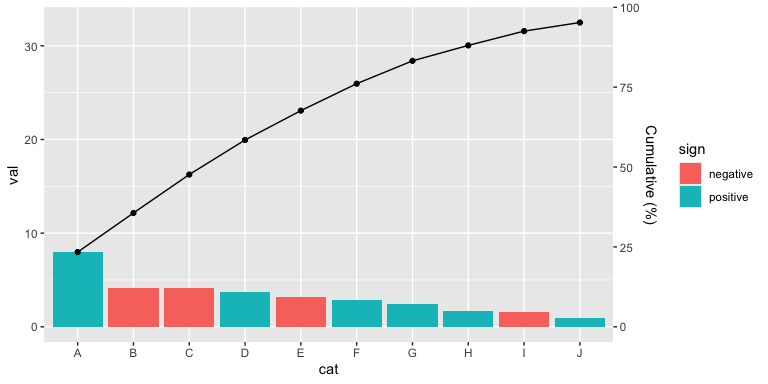

```r
set.seed(1)
tibble(
  val=rnorm(10, sd=5),
  cat=LETTERS[1:length(val)]
  ) %>%
  ggplot(aes(x=cat, y=val)) +
  geom_pareto_bars() +
  geom_pareto_line() +
  geom_pareto_point() +
  scale_y_pareto()
```

For the case of a linear model, there is a conveniency function `pareto_chart()`:

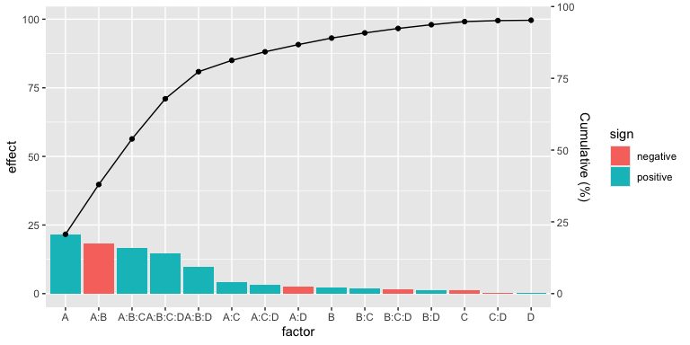

```r
filtration %>%
  lm(Y~A*B*C*D, data=.) %>%
  pareto_chart()
```

### Daniel’s plot

In case of non-replicated factorial plans, the Daniel’s plot can be used to identify the most important factors: a quantile-quantile plot of the factors effects shows the significant factors and interactions off the diagonal.

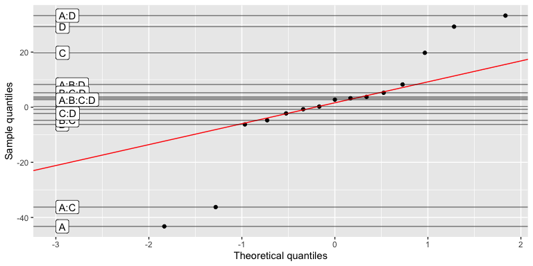

```r
daniel_plot_qq(lm(Y~A*B*C*D, data=filtration))
```

If you prefer, you can rather use a half-normal plot via the conveniency function `daniel_plot_hn`:

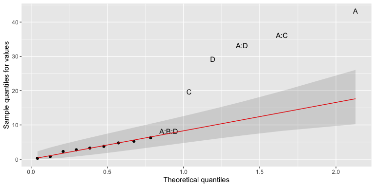

```r
filtration %>%
  lm(Y~A*B*C*D, data=.) %>%
  daniel_plot_hn(label_n = 6)
```

Or, at a lower level:

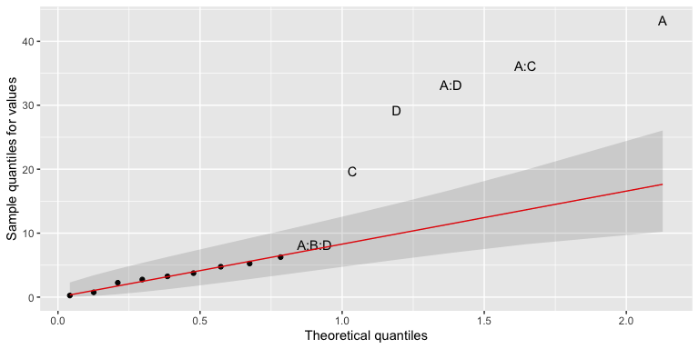

```r
filtration %>%
  lm(Y~A*B*C*D, data=.) %>%
  effects() %>% tail(-1) %>% tibble(factors = names(.), values=.) %>%
  ggplot(aes(sample=values, labels=factors)) +
  geom_qqhn(label_n = 6) +
  geom_qqhn_line(line.p = c(0, 0.4), color="red") +
  geom_qqhn_band(line.p = c(0, 0.4), alpha=0.15)
```

It shows that none of the effects containing the `B` factor are significant, so we can reduce the model to `Y~A*C*D`:

```r
filtration %>%
  lm(Y~A*C*D, data=.) %>%
  anova()
```

```
#> Analysis of Variance Table
#>
#> Response: Y
#>           Df  Sum Sq Mean Sq F value    Pr(>F)
#> A          1 1870.56 1870.56 83.3677 1.667e-05 ***
#> C          1  390.06  390.06 17.3844 0.0031244 **
#> D          1  855.56  855.56 38.1309 0.0002666 ***
#> A:C        1 1314.06 1314.06 58.5655 6.001e-05 ***
#> A:D        1 1105.56 1105.56 49.2730 0.0001105 ***
#> C:D        1    5.06    5.06  0.2256 0.6474830
#> A:C:D      1   10.56   10.56  0.4708 0.5120321
#> Residuals  8  179.50   22.44
#> ---
#> Signif. codes:  0 '***' 0.001 '**' 0.01 '*' 0.05 '.' 0.1 ' ' 1
```

Even better, the model can be further reduced to `Y~A*C+A*D`. Compare this conclusion with the last Pareto chart above.

### Tukey’s test plot

The `stats::TukeyHSD` function in base R provides a way to perform multiple comparisons of means. It can print the results in tabular form or can be plotted with the `plot` method:

```r
data <- battery %>%
  mutate(Material = LETTERS[Material])

data.t <- data %>%
  filter(Material == "A") %>%
  aov(Response~Temperature, data=.) %>%
  TukeyHSD()

data.t
```

```
#>   Tukey multiple comparisons of means
#>     95% family-wise confidence level
#>
#> Fit: aov(formula = Response ~ Temperature, data = .)
#>
#> $Temperature
#>          diff        lwr       upr     p adj
#> 70-15  -77.50 -143.32301 -11.67699 0.0231382
#> 125-15 -77.25 -143.07301 -11.42699 0.0235206
#> 125-70   0.25  -65.57301  66.07301 0.9999380
```

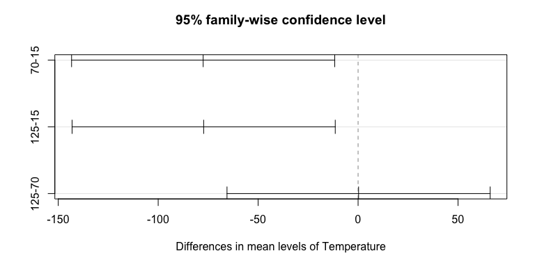

```r
data.t %>% plot()
```

We provide the `ggTukey` function, that uses `ggplot` to provide a better visualization of the results, with the added advantage of allowing to group the plot by a second factor. It can accept a `TukeyHSD` object:

```r
data.t %>%
  ggTukey()
```

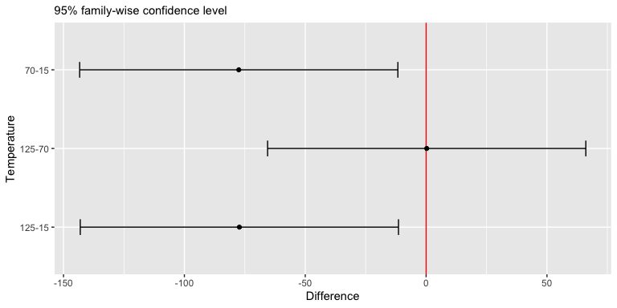

Or a data frame and a formula:

```r
data %>%
  filter(Material == "A") %>%
  ggTukey(Response~Temperature)
```

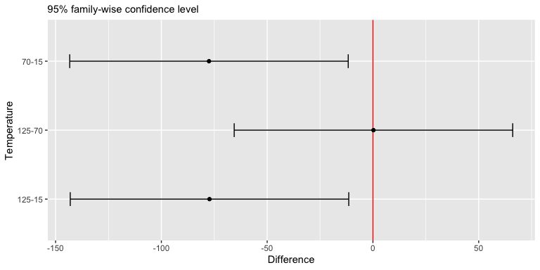

Or a formula and a second split factor formula:

```r
data %>%
  ggTukey(Response~Temperature, splt=~Material)
```

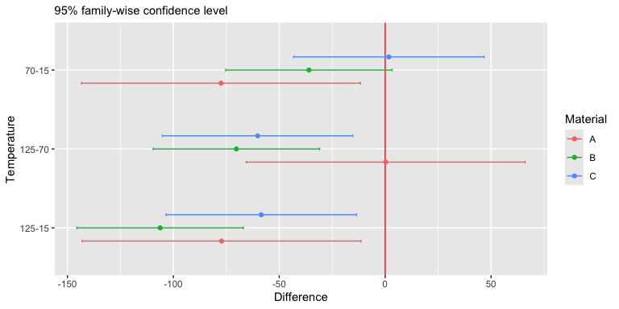

# Utilities

## Data loading

This package also provides a function for easily loading data files made available on the accompanying course documentation on https://paolobosetti.quarto.pub/data:

```r
examples_url("battery.dat") %>%  read.table(header=TRUE)
```

```
#>    RunOrder StandardOrder Temperature Material Repeat Response
#> 1        34             1          15        1      1      130
#> 2        25             2          70        1      1       34
#> 3        16             3         125        1      1       20
#> 4         7             4          15        2      1      150
#> 5         8             5          70        2      1      136
#> 6         1             6         125        2      1       25
#> 7        26             7          15        3      1      138
#> 8        36             8          70        3      1      174
#> 9         6             9         125        3      1       96
#> 10       13            10          15        1      2      155
#> 11        3            11          70        1      2       40
#> 12       31            12         125        1      2       70
#> 13       27            13          15        2      2      188
#> 14       29            14          70        2      2      122
```

[output cut: 22 more lines]

## Imported from `modelr` package

The `modelr` package has been marked as superseded and it is not actively maintained anymore. It provides useful function, though: `add_predictions()` and `add_residuals()`. These functions have been imported into `adas.utils`, with a slight change: `add_predictions()` also accepts further arguments `...` that are passed down to the underlying `predict()` function. This allows to pass the option `interval = c("none", "confidence", "prediction")`:

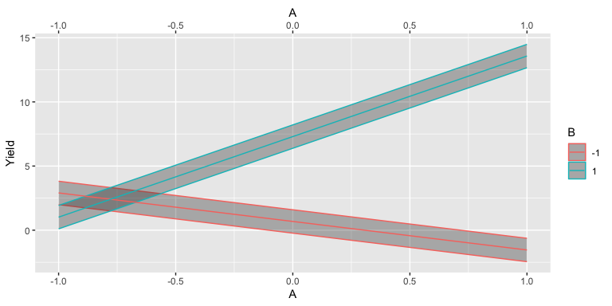

```r
p <- fp_design_matrix(2, rep=3) %>%
  fp_add_names(A="Temperature (°C)", B="Pressure (bar)") %>%
  fp_add_scale(A=c(20,30), B=c(2, 3))
fp$Y <- ccd_experiment_yield$base
fp.lm <- lm(Y~A*B, data=fp)

fp %>%
  add_predictions(fp.lm, interval="confidence") %>%
  mutate(B=factor(B)) %>%
  ggplot(aes(x=A, y=fit, color=B)) +
  geom_ribbon(aes(ymin=lwr, ymax=upr), alpha=1/3) +
  geom_line() +
  scale_x_continuous(sec.axis = fp_scaled_axis(fp, "A"))+
  scale_color_discrete(labels = fp_scale(fp, "B")) +
  labs(color=fp_name(fp, "B"), y="Yield")
```